# Naples Reef (2010*) purple urchins

Jaxon Stuhr

10/27/2021

## Task Overview

This code wrangles and analyzes data on the size and prevalence of purple urchins at the Naples reef near Santa Barbara, CA from 2010. Some observed urchins were subject to a treatment in which kelp was removed once, annually, while others were not, and comparison statistics are examined.

**Data citation:**

Reed, D. 2020. SBC LTER: Reef: Long-term experiment: Kelp removal: Urchin size frequency distribution ver 20. Environmental Data Initiative. https://doi.org/10.6073/pasta/5a1e9ef03aa47bd2225c0bb98a02a63b.

```r
knitr::opts_chunk$set(echo = TRUE, warning = FALSE, message = FALSE)
library(tidyverse)
library(janitor)
library(here)
library(kableExtra)
library(lubridate)
```

```r
# read in urchins data
urchins = read_csv(here("data", "urchins.csv"))
```

```r
# clean up dates and add year column
urchins_clean = urchins %>%
  mutate(DATE = myd(DATE)) %>%
  mutate(YEAR = year(DATE))
```

## Histogram and Quantile-Quantile Plots of Urchins based on Treatment

Here only purple urchins from the Naples reef that were observed in 2010 are considered. A treatment group, “Annual” in which kelp was removed once per winter was compared to a “Control” in which kelp was never removed.

```r
# filter for year = 2010, name = purple urchin, site = Naples reef
naples_purple_2010_urchins = urchins_clean %>%
  filter(YEAR == 2010, COMMON_NAME == "Purple Urchin", SITE == "NAPL")
```

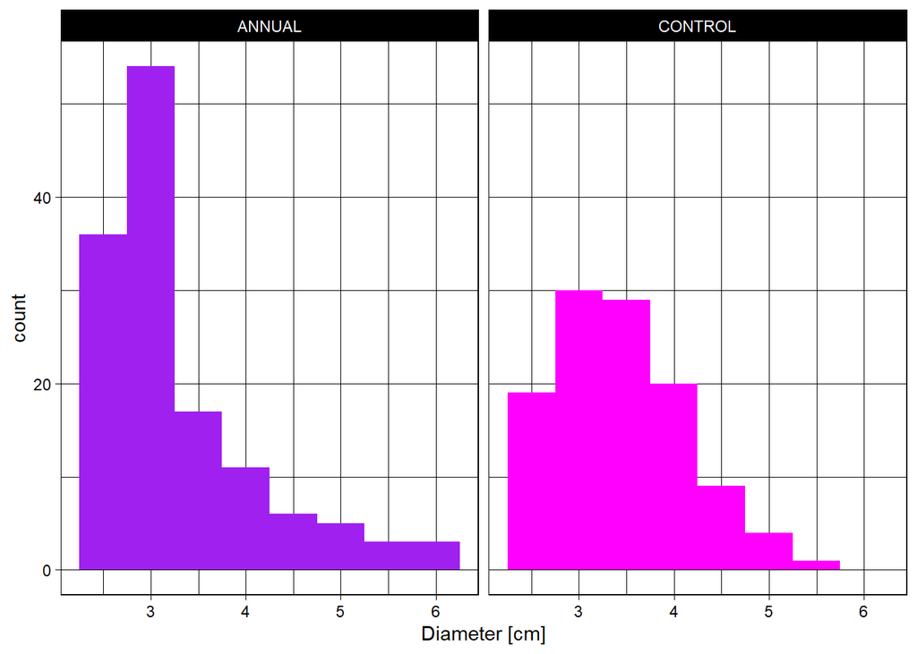

```r
# start w nap purp 2010 data, fill by treatment
ggplot(naples_purple_2010_urchins, aes(x = SIZE, fill = TREATMENT)) +
  # histogram w 8 bins
  geom_histogram(bins = 8) +
  # edit labels
  labs(x = "Diameter [cm]") +
  # control colors
  scale_fill_manual(values=c("Purple", "Magenta")) +
  #facet wrap by treatment
  facet_wrap(~ TREATMENT) +
  # change theme
  theme_linedraw() +
  # mute legend
  guides(fill = FALSE)
```

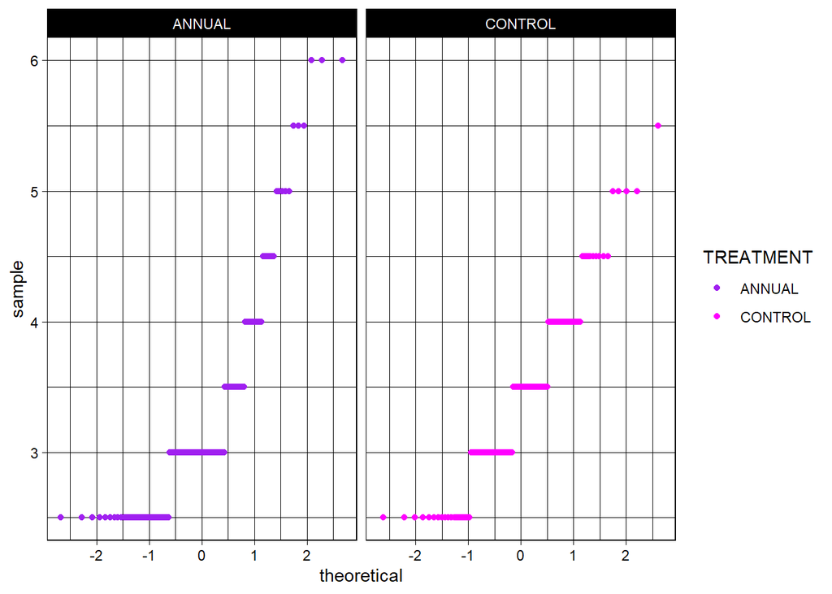

```r
# start w nap purp 2010 data, color by treatment
ggplot(naples_purple_2010_urchins, aes(sample = SIZE, color = TREATMENT)) +
  # quantil quantil plot
  geom_qq() +
  # control colors
  scale_color_manual(values=c("Purple", "Magenta")) +
  # facet wrap by treatment
  facet_wrap(~ TREATMENT) +
  # change theme
  theme_linedraw() +
  # mute legend
  guides(fill = FALSE)
```

## Summary Table of Urchin Statistics

```r
# start w ze urchins
nap_purp_10_summary_table = naples_purple_2010_urchins %>%
  # group by treatment
  group_by(TREATMENT) %>%
  # summary tbl w mean, std, sample size
  summarise(
    mean_size = round(mean(SIZE),1),
    std_size = round(sd(SIZE),1),
    sample_size = n()
  )

nap_purp_10_summary_table %>%
  # build table w kbl extra, rename columns
  kbl(
    caption = "Table 1: Purple Urchins at Naples Reef in 2010 Summary Statistics",
    # name columns
    col.names = c("Treatment", "Mean Diameter [cm]", "Standard Deviation [cm]", "Sample Size")) %>%
  # make the table purty
  kable_classic(full_width = F, html_font = "Cambria")
```

Table 1: Purple Urchins at Naples Reef in 2010 Summary Statistics

| Treatment | Mean Diameter [cm] | Standard Deviation [cm] | Sample Size |
| --- | --- | --- | --- |
| ANNUAL | 3.3 | 0.8 | 135 |
| CONTROL | 3.4 | 0.7 | 112 |

### Summary Statistics Table Analysis

In examining the summary statistics, it appears the kelp removal treatment had little effect on the purple urchins around Naples reef in 2010. The mean diameters for both treated and untreated urchins differed by only 1 mm, as well as the two groups standard deviations. This doesn’t quite tell the whole story, however, as the treated group reached it’s standard deviation by having a very narrow peak with a very long tail, while the control group had a wider peak but a shorter tail.